# Text clustering

## Instruction

```r
data('movie_review')

# your R code to load the data here
movie_review <- as_tibble(movie_review)
# Save sentiment for later use
sentiment_backup <- movie_review[,c(1,2)]
```

# 1. Data description

The data used in this assignment consists of 5000 movie reviews. The reviews are scored on a sentiment score where low ratings are assigned to 0 and high ratings are assigned to 1. As can be seen in the word cloud below, the words ‘movie’, ‘the’ and ‘film’ are used very frequently. These are considered stop words and will be dealt with later on.

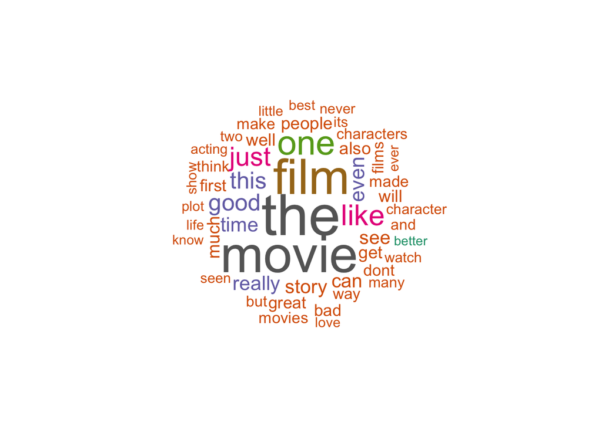

```r
# your R code to generate the plots here
movie_review %$% wordcloud(review,
                           min.freq = 10,
                           max.words = 50,
                           random.order = FALSE,
                           colors = brewer.pal(8, 'Dark2'))
```

# 2. Text pre-processing

```r
# Define negation as all words ending with 'n't' and all occurrences of 'not' or 'no'
negation_pattern <- '(\\w+[nN]\'[tT]\\b)|(\\b[Nn][oO][tT]?\\b)'

# Count negations in the text
negations_bol <- str_detect(movie_review$review, negation_pattern)
cat('There are', sum(negations_bol), 'reviews containing negations (not/no/verb negative affixe)')
```

```
There are 4282 reviews containing negations (not/no/verb negative affixe)
```

We unnest the tokens twice, first classically to spellcheck, remove the stop words, lowercase and perform stemming, secondly without splitting negation terms, as they often carry emotional valence.

```r
# Tokenize data once to perform usual pre-processing
tokenized_data <- movie_review %>%
  unnest_tokens(word, review)
```

```r
# The next commented block performs spell check on the million of rows we have, hence
# its run time is extremely long. To avoid doing it again, the results are saved in a .csv.
# You don't need to run it, the next part of the code reads from the temp_tokens.csv
##########################################################################################
# # Get the spell suggestions
# tokenized_data$Suggestions <- sapply(tokenized_data$word, function(x) hunspell_suggest(x))

# # Only keep the first spell suggestion
# tokenized_data <- tokenized_data %>% mutate(Suggestions = map_chr(Suggestions, first))

# # Check if word exists
# tokenized_data$spell_check <- sapply(tokenized_data$word, function(x) hunspell_check(x))

# # Backup to .csv
# write_csv2(tokenized_data,'temp_tokens.csv')
##########################################################################################
```

For the spell check, all non existing words are replaced by the first spell suggestion of hunspell.

```r
# Read the tokenized dataframe including spell check
tokenized_data <- read_csv2('temp_tokens.csv')

# Keep trace of initial word
names(tokenized_data)[names(tokenized_data) == 'word'] <- 'old_word'

# Create new 'word' column
tokenized_data <- tokenized_data %>% mutate(word = case_when(
  # word is switched to lowercased spell suggestion when spell check is false
  spell_check == FALSE ~ tolower(Suggestions),
  # else the initial word is kept
  spell_check == TRUE ~ old_word))
```

Number were also removed after we noticed how much there were. We keep the negation information by tokenizing group of words when they occur (the negation and the following non stop word). We first tag all the negations the same to reduce the number of possible negation terms.

```r
# Replace negations by a single tag
tokenized_data <- mutate(tokenized_data, word = str_replace_all(word, negation_pattern, 'negationtag'))
```

To adjust the stop word list, we plot the most frequent words. As can be seen below, the word count adhere to Zipf’s law, i.e. a few words such as ‘the’ occur very frequently and most of the words occur rarely.

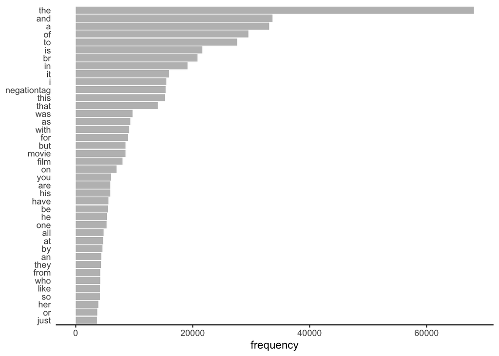

```r
gg1 <- tokenized_data %>%
  # count the frequency of each word
  count(word) %>%
  # arrange the words by its frequency in descending order
  arrange(desc(n)) %>%
  # select the most frequent words
  head(40) %>%
  # make a bar plot (reorder words by their frequencies)
  ggplot(aes(x = n, y = reorder(word, n))) +
  geom_col(fill='gray') +
  labs(x = 'frequency') +
  theme_classic() +
  theme(axis.title.y = element_blank(), axis.line.y = element_blank(), axis.ticks.y = element_blank())
gg1
```

Stop words prevail. As we saw before, there are a lot of negations. We’ll add ‘br’,‘movie’, ‘film’ to the stop words list.

```r
# Create our stop words list
df_stopwords <- stop_words %>%
  rbind(tibble(word = c('br','film', 'movie'), lexicon = c('me', 'me', 'me')))

# Remove stop words
tokenized_data <- tokenized_data %>%
  anti_join(df_stopwords) %>%
  # Perform stemming
  mutate(word = wordStem(word, language = 'english'))
```

```r
# Now the negations groups are split. We first rebuilt the complete reviews
movie_review <- tokenized_data %>%
  group_by(id) %>%
  summarize(review = paste(word, collapse = ' '))

# Remove numbers
movie_review <- mutate(movie_review, review = str_replace_all(review, '\\d', ''))
```

```r
# Tokenize back keeping each pair of negation tag and following word together
tokenized_data <- movie_review %>%
  # split where there is a non word (except ') not preceded by a negation tag
  unnest_tokens(terms, review, token = 'regex', pattern = '(?<!negationtag)[^\'\\w]')

# Glimpse at the negation groups
cat('Examples of negation terms :\n', tail(str_subset(tokenized_data$terms, 'negationtag'), 3))
```

```
Examples of negation terms :
 negationtag bad negationtag check negationtag violent
```

# 3. Text representation

In our implementation, we set the window size to 5, the embedding length to 50 and pruned the terms that appeared less than 5 times.

```r
set.seed(1)
# Create a vocabulary of the distinct terms
terms_ls <- list(tokenized_data$terms)
it <- itoken(terms_ls, progressbar = FALSE)
review_vocab <- create_vocabulary(it)
# filter the infrequent terms (number of occurrence is less than 5)
review_vocab <- prune_vocabulary(review_vocab, term_count_min = 5)
# maps words to indices
vectorizer <- vocab_vectorizer(review_vocab)
# use window of 5 for context words
review_tcm <- create_tcm(it, vectorizer, skip_grams_window = 5)
# set embeddings length to 50 and maximum number of co occurences to 10
glove <- GlobalVectors$new(rank = 50, x_max = 10)
review_wv_main <- glove$fit_transform(review_tcm, n_iter = 20, convergence_tol = 0.001, n_threads = 1) #n_threads for reproducibility
```

```
INFO  [19:21:44.765] epoch 1, loss 0.1032
INFO  [19:21:45.637] epoch 2, loss 0.0703
INFO  [19:21:46.317] epoch 3, loss 0.0626
INFO  [19:21:47.041] epoch 4, loss 0.0580
INFO  [19:21:47.893] epoch 5, loss 0.0547
INFO  [19:21:48.660] epoch 6, loss 0.0522
INFO  [19:21:49.371] epoch 7, loss 0.0502
INFO  [19:21:50.140] epoch 8, loss 0.0486
INFO  [19:21:50.800] epoch 9, loss 0.0472
INFO  [19:21:51.463] epoch 10, loss 0.0461
INFO  [19:21:52.115] epoch 11, loss 0.0451
INFO  [19:21:52.842] epoch 12, loss 0.0442
INFO  [19:21:53.509] epoch 13, loss 0.0434
INFO  [19:21:54.171] epoch 14, loss 0.0427
INFO  [19:21:54.942] epoch 15, loss 0.0421
INFO  [19:21:55.622] epoch 16, loss 0.0416
INFO  [19:21:56.277] epoch 17, loss 0.0411
INFO  [19:21:56.962] epoch 18, loss 0.0406
INFO  [19:21:57.674] epoch 19, loss 0.0402
INFO  [19:21:58.370] epoch 20, loss 0.0398
```

```r
# extract context word vector
review_wv_context <- glove$components
# Create embeddings matrix as the sum of the context and target matrices
review_word_vectors <- review_wv_main + t(review_wv_context) # transpose one matrix to perform matrix addition
```

# 4. Text clustering

We represented each review by the average of the embeddings of the terms in it.

We performed k-means clustering and Gaussian mixture models (GMM). GMM are a model based clustering approach which assumes that the data within a predefined number of clusters are normally distributed (an assumption we made as our data was averaged). Based on that assumption, the probabilistic (soft) assignment of each point to a class can be estimated by expectation maximization. During this step, the likelihood of the data is maximized by adjusting several parameters of the clusters distributions : the mean of each cluster, (related to their locations), the proportions of points (related to their sizes), the variances and covariances (related to their volume, shape and orientation). The later parameters can be equal between all clusters in simpler models, or they can vary.

K-means clustering is equivalent to a GMM with equal volumes, and shapes and orientation fixed to 1. Contrary to GMM, it performs a hard assignment of the points to the clusters. We chose this model as useful comparison to GMM since it doesn’t make a normality assumption.

```r
# Map embeddings and reviews
# Tidy glove output to dataframe, getting back the terms as column
embeddings <- data.frame(review_word_vectors) %>%
  tibble::rownames_to_column('terms')
# Add embeddings to the table that maps terms and reviews
tokenized_data <- merge(tokenized_data, embeddings, by = 'terms')
# Define embeddings subset for clustering
feature_columns <- colnames(tokenized_data)[!(colnames(tokenized_data) %in% c('terms', 'id'))]
# Create dataframe mapping reviews to the average embeddings
reviews_for_clust <- tokenized_data %>%
    # Get average embeddings by review
    group_by(id) %>%
    summarise(across(feature_columns, mean))
```

## k-means

Each element of the average vector is just like a feature. So for each review (observation) we have 50 features. We can find the similarity between these features and cluster our observations based on them.

Applying the k-means algorithm, using 5 clusters. We set the nstart parameter to 40, to take 40 times different starting centroids to lessen the effect of random initialization of the k-means algorithm.

```r
set.seed(1)
# Perform k-means clustering for 5 clusters
kmeans_model_5 <- select(reviews_for_clust, feature_columns) %>%
  kmeans(centers = 5, iter.max = 20, nstart = 40)

# Perform k-means clustering for 10 clusters
kmeans_model_10 <- select(reviews_for_clust, feature_columns) %>%
  kmeans(centers = 10, iter.max = 20, nstart = 40)
```

## Gaussian Mixture Model

```r
# GMM with 5 clusters
set.seed(1)
gmm_5 <- select(reviews_for_clust, feature_columns) %>%
  Mclust(G = 5)

#finding the best model:
cat('best GMM with 5 groups is type', gmm_5$modelName)
```

```
best GMM with 5 groups is type EEV
```

```r
#showing the summary stats
summary(gmm_5)
```

```
----------------------------------------------------
Gaussian finite mixture model fitted by EM algorithm
----------------------------------------------------

Mclust EEV (ellipsoidal, equal volume and shape) model with 5 components:

 log-likelihood    n   df      BIC    ICL
       286848.5 5000 6429 518939.9 517786

Clustering table:
   1    2    3    4    5
 565 2572  355 1423   85
```

```r
# GMM with 10 clusters
set.seed(1)
gmm_10 <- select(reviews_for_clust, feature_columns) %>%
  Mclust(G = 10)

#finding the best model:
cat('best GMM with 10 groups type is', gmm_10$modelName)
```

```
best GMM with 10 groups type is EEI
```

```r
#showing summary statistics
summary(gmm_10)
```

```
----------------------------------------------------
Gaussian finite mixture model fitted by EM algorithm
----------------------------------------------------

Mclust EEI (diagonal, equal volume and shape) model with 10 components:

 log-likelihood    n  df      BIC      ICL
         243795 5000 559 482828.8 481941.4

Clustering table:
   1    2    3    4    5    6    7    8    9   10
 491 1242  886 1822   18   12    1  524    3    1
```

```r
# Add the cluster assignments to results dataframe
reviews_for_clust$kmeans_5 <- kmeans_model_5$cluster
reviews_for_clust$kmeans_10 <- kmeans_model_10$cluster
reviews_for_clust$gmm_5 <- gmm_5$classification
reviews_for_clust$gmm_10 <- gmm_10$classification
# Add sentiment column to results dataframe
reviews_for_clust <- merge(reviews_for_clust, sentiment_backup, by = 'id')
```

# 5. Evaluation & model comparison

We visualized the results in UMAP 2D manifold.

The clustering evaluation was based on internal metrics, such as mean silhouette. The average silhouette index provides an indication of the degree to which points belong to their clusters, on the scale of the clustering as a whole. It consists of comparing the average distance between a point and the members of its cluster, with the distance between this same point of interest and the nearest point not belonging to the same cluster. A perfect silhouette is equal to 1, while negative scores reflect poor structure of the results. It is worth noting that this kind of metric tries to emphasize the homogeneity within cluster and the distance between cluster but is less suited whenever the true classes are not shaped such that the same cluster points always are the closest neighbors. The BIC was used to compare the GMMs ; this metric reflects the lack of fit of the model and its complexity, hence is minimized.

We also assessed the relation between our results and an external feature, the binary sentiment score, using Khi-square test with a correction for multiple testing (alpha = 0.05/4).

## Visualization of the results

```r
# Project results in 2D manifold using UMAP
set.seed(1)  # reproducibility of umap
umap <- umap(reviews_for_clust[feature_columns])

plot_2d <- data.frame(x = umap$layout[,1],
                 y = umap$layout[,2],
                 kmeans_5 = reviews_for_clust$kmeans_5,
                 kmeans_10 = reviews_for_clust$kmeans_10,
                 gmm_5 = reviews_for_clust$gmm_5,
                 gmm_10 = reviews_for_clust$gmm_10)
```

```r
palette <- c('firebrick1', 'limegreen', 'darkorchid2', 'tan4', 'midnightblue', 'cyan', 'slategrey', 'gray7', 'lemonchiffon4','violetred1')
# Scatterplots in 2D manifold
scat_plot <- function(dataframe, x_axis, y_axis, color){
  suppressMessages({
    p <- ggplot(dataframe, aes(x_axis, y_axis, colour = as.factor(color))) +
  geom_point(alpha = 0.3) +
  xlim(-3.5,3.5) +
  ylim(-4.5, 4.5) +
  theme_void() +
  guides(color = 'none') +
  scale_color_manual(values = palette)
  })
  return(p)
}
# Apply for each clustering
scat_k5 <- scat_plot(plot_2d, plot_2d$x, plot_2d$y, plot_2d$kmeans_5)
scat_k10 <- scat_plot(plot_2d, plot_2d$x, plot_2d$y, plot_2d$kmeans_10)
scat_gmm5 <- scat_plot(plot_2d, plot_2d$x, plot_2d$y, plot_2d$gmm_5)
scat_gmm10 <- scat_plot(plot_2d, plot_2d$x, plot_2d$y, plot_2d$gmm_10)

# Conjunction plot cluster and sentiment
conj_plot <- function(dataframe, x_axis, fill){
  suppressMessages({
    p <- ggplot(dataframe, aes(x_axis, fill = as.factor(fill))) +
  geom_bar() +
  theme_classic() +
  scale_fill_manual(values = c('red', 'green'))  +
  guides(fill="none") +
  labs(x = 'cluster') +
  theme(axis.text = element_blank(), axis.title.y = element_blank(), axis.line.y = element_blank(), axis.ticks = element_blank())

  })
  return(p)
}

# Apply for each clustering
conj_k5 <- conj_plot(reviews_for_clust, reviews_for_clust$kmeans_5, reviews_for_clust$sentiment)
conj_k10 <- conj_plot(reviews_for_clust, reviews_for_clust$kmeans_10, reviews_for_clust$sentiment)
conj_gmm5 <- conj_plot(reviews_for_clust, reviews_for_clust$gmm_5, reviews_for_clust$sentiment)
conj_gmm10 <- conj_plot(reviews_for_clust, reviews_for_clust$gmm_10, reviews_for_clust$sentiment)
```

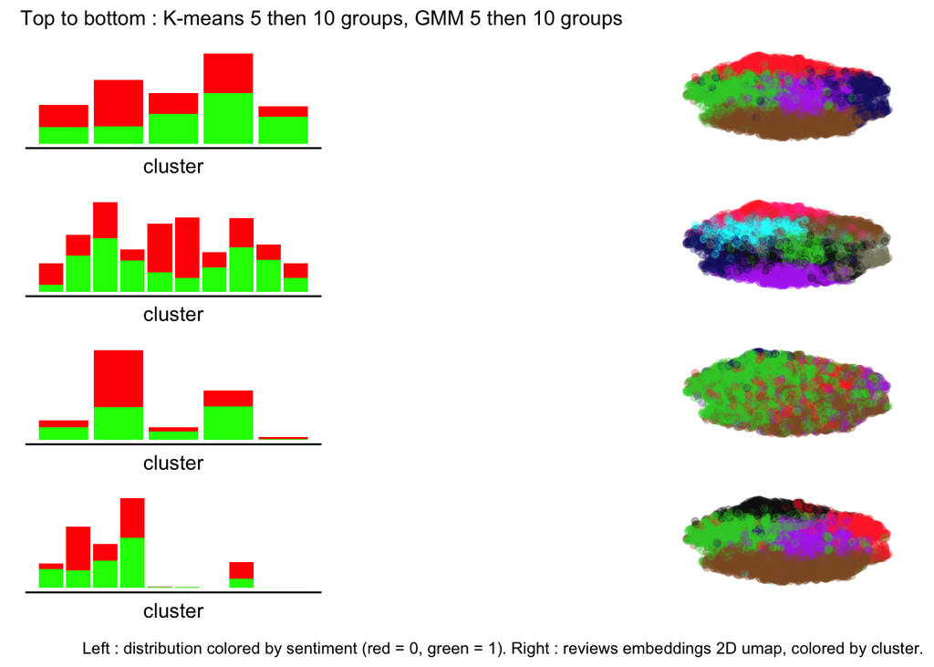

```r
# Assemble graphs
layout <- "
A#B
C#D
E#F
G#H
"

conj_k5 + scat_k5 + conj_k10 + scat_k10 + conj_gmm5 + scat_gmm5 + conj_gmm10 + scat_gmm10 + plot_layout(design = layout) + plot_annotation(
  subtitle = 'Top to bottom : K-means 5 then 10 groups, GMM 5 then 10 groups',
  caption = 'Left : distribution colored by sentiment (red = 0, green = 1). Right : reviews embeddings 2D umap, colored by cluster.'
)
```

GMMs tend to have some poorly populated clusters.

## Internal validation

Retrieving the within-cluster sum of squares for both k-means clusterings

```r
# the within-cluster sum of scores for kmeans methods
kmeans5_wcss <- kmeans_model_5$tot.withinss
kmeans10_wcss <- kmeans_model_10$tot.withinss

# the within-cluster sum of scores for GMM methods
scores_gmm_5 = cluster.stats(dist(reviews_for_clust[feature_columns]), gmm_5$classification)
scores_gmm_10 = cluster.stats(dist(reviews_for_clust[feature_columns]), gmm_10$classification)

gmm5_wcss <- scores_gmm_5$within.cluster.ss
gmm10_wcss <- scores_gmm_10$within.cluster.ss

cat('the within-cluster sum of squares for\n',
'kmeans with 5 clusters:',
kmeans5_wcss,'\n',
'kmeans with 10 clusters: ',
kmeans10_wcss,'\n',
'GMM with 5 clusters: ',
gmm5_wcss,'\n',
'GMM with 10 clusters: ',
gmm10_wcss)
```

```
the within-cluster sum of squares for
 kmeans with 5 clusters: 2011.768
 kmeans with 10 clusters:  1862.862
 GMM with 5 clusters:  2558.564
 GMM with 10 clusters:  2522.155
```

As results show, the kmeans algorithm with 10 clusters has a bit smaller within-cluster sum of squares value, which is more desirable.

```r
si_kmeans_5 <- silhouette(reviews_for_clust$kmeans_5, dist(reviews_for_clust[feature_columns]))
si_kmeans_10 <- silhouette(reviews_for_clust$kmeans_10, dist(reviews_for_clust[feature_columns]))

kmeans5_sis<- mean(si_kmeans_5[,3])
kmeans10_sis <- mean(si_kmeans_10[,3])

gmm5_sis <- scores_gmm_5$avg.silwidth
gmm10_sis <- scores_gmm_10$avg.silwidth
```

## External validation

Chi-square to test the relation between clusters and sentiment :

```r
kmeans_5_table <- table(reviews_for_clust$kmeans_5, reviews_for_clust$sentiment)
chisq.test(kmeans_5_table)
```

```
    Pearson's Chi-squared test

data:  kmeans_5_table
X-squared = 431.56, df = 4, p-value < 2.2e-16
```

```r
kmeans_10_table <- table(reviews_for_clust$kmeans_10, reviews_for_clust$sentiment)
chisq.test(kmeans_10_table)
```

```
    Pearson's Chi-squared test

data:  kmeans_10_table
X-squared = 709.57, df = 9, p-value < 2.2e-16
```

```r
gmm_5_table <- table(reviews_for_clust$gmm_5, reviews_for_clust$sentiment)
chisq.test(gmm_5_table)
```

```
    Pearson's Chi-squared test

data:  gmm_5_table
X-squared = 461.8, df = 4, p-value < 2.2e-16
```

```r
gmm_10_table <- table(reviews_for_clust$gmm_10, reviews_for_clust$sentiment)
chisq.test(gmm_10_table)
```

```
    Pearson's Chi-squared test

data:  gmm_10_table
X-squared = 486.99, df = 9, p-value < 2.2e-16
```

## Evaluation summary

```r
data.frame(
  'Model' = c('K-means 5', 'K-means 10',  'GMM 5', 'GMM 10'),
  'Silhouette'  = c(kmeans5_sis, kmeans10_sis, gmm5_sis, gmm10_sis),
  'BIC' = c('nc', 'nc', summary(gmm_5)$bic, summary(gmm_10)$bic),
  'Chi2'      = c(summary(kmeans_5_table)$statistic, summary(kmeans_10_table)$statistic, summary(gmm_5_table)$statistic, summary(gmm_10_table)$statistic),
  'Chi2 p-value' = c(summary(kmeans_5_table)$p.value, summary(kmeans_10_table)$p.value, summary(gmm_5_table)$p.value, summary(gmm_10_table)$p.value)
)
```

| Model | Silhouette | BIC | Chi2 | Chi2.p.value |
| --- | --- | --- | --- | --- |
| K-means 5 | 0.0648219 | nc | 431.5583 | 0 |
| K-means 10 | 0.0354979 | nc | 709.5707 | 0 |
| GMM 5 | -0.0070909 | 518939.868755275 | 461.8021 | 0 |
| GMM 10 | -0.2263733 | 482828.828043235 | 486.9860 | 0 |

All average silhouette are weak, reflecting a lack of structure as assessed by the silhouette index. This result is in accordance with the 2D representation of reviews embeddings : these embeddings form a very dense rather normal distribution. Hence, the silhouette is minimized by the proximity with the other cluster points.

Chi-squared tests are highly significant for all models, suggesting a relationship between cluster and sentiment. This is a lucky result since the external validation feature we used was picked by default of other choice. Indeed, embeddings dimensions a not easily interpretable, and can capture a wide range of semantic aspects (grammatical properties, emotional valence, lexical field). Glimpsing at the reviews, we saw that a lot of them were not clear short worded comments, but rather a long description of the movies plots. Therefore, there was no strong reason to assume that the averaged terms embeddings per review would be best characterized by emotional valence.

In more details, due to the nature of the Chi-squared formula (χ² = Σ [(O - E)² / E]), a higher X-squared value suggests a greater discrepancy between observed and expected values. According to that metric, the K-means clustering with 10 groups is by far the most related to the sentiment.

```r
# Represent each cluster by its average embedding
kmeans_10_averaged <- reviews_for_clust %>%
    # Get average embeddings by GMM 10 cluster
    group_by(kmeans_10) %>%
    summarise(across(feature_columns, mean))

# for each cluster
pairs <- data.frame(
  'Cluster' = c(seq(1:10)),
  'Closest term' = c(rep('', 10)))
for (i in 1:10){
  highest_sim = -10
  # compare cluster's average embedding to each term in the vocabulary
  for (j in 1:nrow(embeddings)){
    sim <- cosine(as.numeric(as.vector(kmeans_10_averaged[i,-1])), as.numeric(as.vector(embeddings[j,-1])))
    if (sim > highest_sim){
      highest_sim <- sim
      pairs[i,2] <- embeddings[j,1]
    }
  }
}
```

Representing each k-means cluster by its average, we can map each cluster to the term with the most similar embedding :

```r
pairs
```

| Cluster | Closest.term |
| --- | --- |
| 1 | bad |
| 2 | actor |
| 3 | time |
| 4 | stori |
| 5 | time |
| 6 | time |
| 7 | watch |
| 8 | stori |
| 9 | time |
| 10 | time |

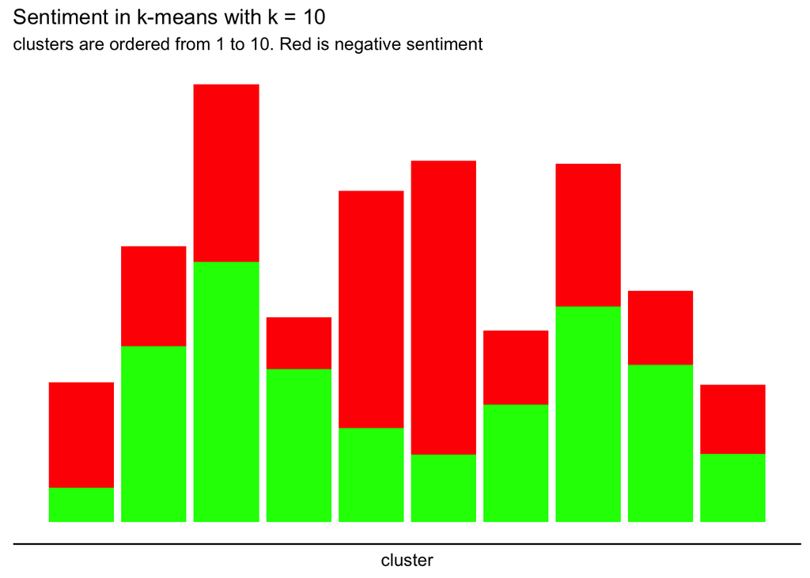

```r
# Replot conjunction of sentiment and k-means 10 clusters
conj_k10 + labs(title = 'Sentiment in k-means with k = 10', subtitle = 'clusters are ordered from 1 to 10. Red is negative sentiment')
```

Overall, the internal indexes show a lack of separation between clusters. There is a relation between the clustering and the sentiment, so the clustering has some kind of interest. We can’t exclude that some unobserved external feature describes way better the clusters than the sentiment does.